# Property Tax Bill Explainer

Get your report by email:

## What are property taxes?

The property tax provides essential funding for operating local services, such as schools, public safety, sanitation, libraries, and parks.

But property tax bills are complex and can be difficult to understand. The goal of this Explainer is to help property owners in Cook County understand their tax bills and why they go up or down from one year to the next.

## Your Property

Each year you receive one tax bill that is split across two payments. The first installment is due by March 1st and will be 55% of the last year’s tax bill. The second installment is sent around June 30 and is for the remaining taxes due.

The information below is from the year 2023, combining both FIRST and SECOND installement tax bills.

| PIN | 16123090200000 | Code that identifies your property |
| --- | --- | --- |
| Market Value | $309,560 | Assessor’s estimate of your property’s value |
| Class | Residential - Two to six residential apartments, any age | Type of property |
| Last Assessment Year | 2021 | Last time the assessor updated estimates of your property value |
| Total Exemptions | 0 | Number of exemptions you claimed |
| Total Exemptions Amount | $0 | Value of exemptions; these are deducted from your property value for tax purposes |
| Total Tax Bill | $6,553.85 | Final amount due on your 2023 bill |

Every **PIN** belongs to multiple tax districts. Your PIN, **Parcel (16-12-309-020-0000)** belongs to the following taxing districts –

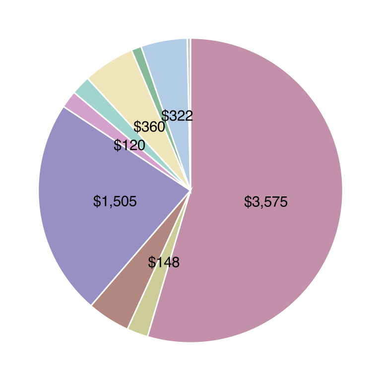

| District | Amount Owed |
| --- | --- |
| County Of Cook | $360.42 |
| Forest Preserve District Of Cook County | $70.03 |
| City Of Chicago | $1,505.17 |
| City Of Chicago Library Fund | $120.45 |
| City Of Chicago School Bldg & Imp Fund | $133.52 |
| Chicago Community College District 508 | $147.53 |
| Board Of Education | $3,575.25 |
| Chicago Park District | $296.93 |
| Metro Water Reclamation District Of Greater Chicago | $322.14 |
| West Side Expanded Mental Health Service District | $22.41 |

Your total tax bill is the result of the taxes you pay to each of these jurisdictions. The pie chart on the right shows how your tax bill was divided among the jurisdictions.

## How Is My Tax Determined?

Your tax bill is determined primarily by two key factors, which are represented in the figure below. First is the assessor’s estimate of your property value, which is based on an analysis of other similar homes that have sold recently. Second is the amount of property taxes charged by the taxing jurisdictions that your property is within, known as the levy. Most properties to belong to multiple taxing jurisdictions, such as a county, city, and school district, and pay a separate tax to each one.

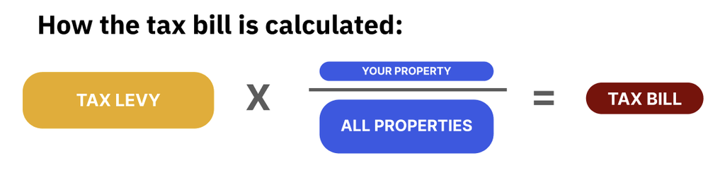

Tax Bill Calculation

Property tax bills are calculated based on the **Tax Levy** and the value of your property. First, the government determines the **Tax Levy**, or the total amount of taxes imposed by the government. This levy is then divided among all property owners in the area. Your share of this levy depends on **how much your property is worth compared to the total value of all properties**.

Your final tax bill reflects your property’s **share of the total taxable value** in the area, meaning you contribute to the Tax Levy in proportion to your property’s worth.

In addition to these two factors, various exemptions that you claim, as well as a state equalization factor, may affect your tax bill. Finally, the tax levy is divided between commercial and residential properties, so changes in commercial valuations may affect residential tax bills. We will explain all of this in the next section and show how these various considerations affect your tax bill.

## Why Did My Property Tax Bill Change From 2021 to 2023?

The tax bill for **Parcel (16-12-309-020-0000)** was approximately $7,061 in 2021 and $6,554 in 2023, representing a **decrease** of **$507**. This change can be broken down into the two main components described above, changes in the levy and changes in assessed values. The most significant change in your bill was due to **your property’s share of all residential properties changing**.

Your tax bill increased by approximately **$614** due to the increase in your taxing districts’ levies. In other words, this is the part of your tax bill that went up because the government collected more taxes in 2023. This is the change in the tax bill outside your control, is the same for everyone, and refers to the increased the cost of providing services.

> There is also a $86 decrease that was caused by a combination of both factors.

The change in your tax bill is depicted in the figure below.

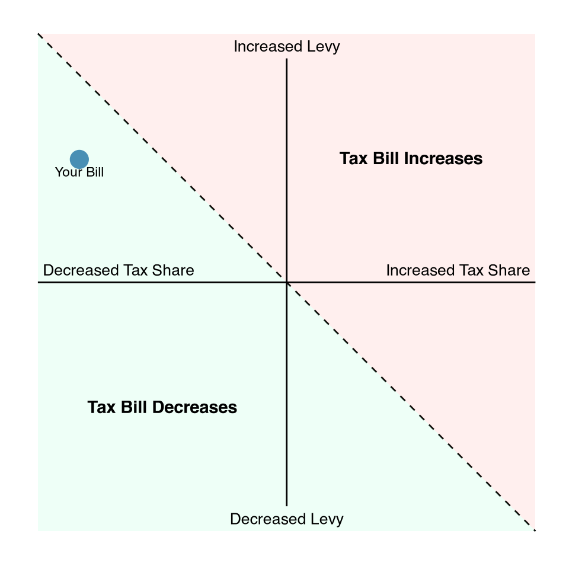

## How did changes in assessments affect my bill?

Your property’s share of the tax base also affects your bill. This share is how much your property’s taxable value, or its Equalized Assessed Value, makes up of the the taxable value of all properties, called the Tax Base. The Tax Base is the combination of the taxable value of all residential and commercial properties.

This share can be broken up into three parts that impact your bill:

**(A) Change in Exemptions**

**(B) Change in your Property’s Share of all Residential Properties**

**(C) Change in Commercial-Residential Ratio**

#### (A) Change from Exemptions

Your tax bill may have changed due to a change in your exemptions. Property tax exemptions are savings that contribute to lowering a homeowner’s property tax bill. Some exemptions need to be claimed each year, while other exemptions continue after being claimed once.

There may be other exemptions that you qualify for. Learn more about exemptions, including how to apply, at the [Cook County Assessor’s Office’s website](https://www.cookcountyaa.gov/property-tax-exemptions).

Your exemptions did not change between 2021 and 2023 so your tax bill did not change.

**Change By Exemption**

NO CHANGE AND NO EXEMPTIONS

#### (B) Change in your Property’s Share of all Residential Properties

Your tax bill will change when there is a change in your property’s taxable value compared to all other properties in your area. Your property’s taxable value **decreased** by **11.15%** from $105K to $93,373. If the estimated market value of your home is significantly more than what you believe your home could sell for in the current real estate market, you may [file an appeal with the Cook County Assessor’s Office](https://www.cookcountyaa.gov/appeal-your-assessment).

Your property’s fair market value (as estimated by the Cook County Assessor’s Office) is $310K. The estimated fair market value is used to calculate your property’s taxable value, called the Equalized Assessed Value (EAV). This year, your EAV was $93,373. See Appendix A for more details about this calculation.

**Change by District**

|  | Change in Tax Amount |  |
| --- | --- | --- |
| Cook County | −$123.04 |  |
| Miscellaneous | −$136.02 |  |
| Municipality/Township | −$239.52 |  |
| School | −$477.19 |  |
| Total Tax Owed | −$975.77 | — |

See the breakdown of the change in EAV Residential Share for each district in Appendix D

#### (C) Change from Commercial-Residential Ratio

Your tax bill may also change when there is a change in how the levy is divided between **all** residential properties compared to **all** commercial properties. When the relative value of commercial property declines, taxes on residential property will go up. In addition, commercial properties are more likely to decrease their assessment value through appeals, which shifts the tax burden more onto residential properties. The share that all residential properties paid in 2023 decreased, which caused your tax bill to **decrease** by **$66**.

**Change by District**

|  | Change in Tax Amount |  |
| --- | --- | --- |
| Cook County | $10.37 |  |
| Miscellaneous | $2.20 |  |
| Municipality/Township | −$26.16 |  |
| School | −$52.10 |  |
| Total Tax Owed | −$65.69 | — |

See the breakdown of the change in Commercial Share for each district in Appendix D

## How did a change in the Tax Levy affect my bill?

Your tax bill changed due to the change in the **Tax Levy**, or the total amount of taxes imposed by the government. The total **Tax Levy** for all tax districts for your property **increased** by **8.15%** between 2023 and 2021 which caused your tax bill to **increase** by **$614**.

**District wise changes in Levies**

|  | Change in Tax Amount |  |
| --- | --- | --- |
| Cook County | $20.27 |  |
| Miscellaneous | $29.89 |  |
| Municipality/Township | $104.14 |  |
| School | $459.64 |  |
| Total Tax Owed | $613.94 | — |

**Appendix A: Calculating Equalized Assessed Value**

First, start with the Fair Market Value and multiply by the Level of Assessment, which is 10% for all residential property, and the State Equalizer, a multiplier whose goal is to make property tax rates roughly equal across all IL counties. Both of these values are the same for all property owners in this area. After this, subtract your valid exemptions. [^1]

The resulting value is the Equalized Assessed Value.
$$\$310K \times 10.00\% \times 3.0163 = \$93,373$$
$$\$93,373 - \$0 = \$93,373$$

**Appendix B: Calculating a Single District’s Tax Bill**

Let’s look at the line item of the bill for **Parcel (16-12-309-020-0000)** in 2023 for **Board Of Education** -

|  | Tax District | Agency Tax Base | Agency Tax Levy | Agency Tax Rate | Final Tax Owed |
| --- | --- | --- | --- | --- | --- |
| School | Board Of Education | $99.65B | $3.82B | 3.83% | $3,575.25 |

For the purpose of operating **Board Of Education**, in 2023, it needs to collect **$4B** in order to provide services.

|  | Tax District | Agency Tax Base | Agency Tax Levy | Agency Tax Rate | Final Tax Owed |
| --- | --- | --- | --- | --- | --- |
| School | Board Of Education | $99.65B | $3.82B | 3.83% | $3,575.25 |

But where can **Board Of Education** raise the money from? From all the properties within the district boundaries!  
The total taxable value of all properties falling in **Board Of Education** make up its **tax base**. For 2023, this was **$100b**

|  | Tax District | Agency Tax Base | Agency Tax Levy | Agency Tax Rate | Final Tax Owed |
| --- | --- | --- | --- | --- | --- |
| School | Board Of Education | $99.65B | $3.82B | 3.83% | $3,575.25 |

The cost of services of **Board Of Education** is therefore divided amongst all the property owners, and **Board Of Education** sets its agency tax rate equal to:

$$\mathrm{{Levy \over Base} = Tax \hspace{0.1cm} rate}$$

Using real numbers, the tax rate equals:
$$\mathrm{\$4B \over \$100B} = 3.83\%$$

|  | Tax District | Agency Tax Base | Agency Tax Levy | Agency Tax Rate | Final Tax Owed |
| --- | --- | --- | --- | --- | --- |
| School | Board Of Education | $99.65B | $3.82B | 3.83% | $3,575.25 |

#### How much do you owe the **Board Of Education**?

As the owner of **Parcel (16-12-309-020-0000)**, in the year 2023 your property is worth **$310k**, of that, your taxable amount (or addition to the tax base) is **$93,373**.

The previously calculated **Rate** is then applied to your **Addition To The Tax Base**:

$$(\$93,373 * 3.83\%) = \$3,575$$

This is the part of your bill that goes to to the **Board Of Education**

|  | Tax District | Agency Tax Base | Agency Tax Levy | Agency Tax Rate | Final Tax Owed |
| --- | --- | --- | --- | --- | --- |
| School | Board Of Education | $99.65B | $3.82B | 3.83% | $3,575.25 |

See Appendix C for a detailed view of your tax bill for each tax district your property is in. This is the same calculation as above, but done for each district your property is in and should match the your tax bill received in the mail.

> Generally, these districts fund the local elementary, middle and high schools, along with community colleges in the area.

> The **Board Of Education** is partially funded by property taxes and runs the Chicago Public Schools system, a K-12 system in the City of Chicago.

> [Chicago Public Schools, Revenue, 2023](https://www.cps.edu/about/finance/budget/budget-2023/revenue/)

**Appendix C: Properties Tax Districts**

|  | Tax District | Agency Tax Base | Agency Tax Levy | Agency Tax Rate | Final Tax Owed |
| --- | --- | --- | --- | --- | --- |
| School | Board Of Education | $99.65B | $3.82B | 3.83% | $3,575.25 |
|  | Chicago Community College District 508 | $99.60B | $157.36M | 0.16% | $147.53 |
| Municipality/Township | City Of Chicago | $99.65B | $1.61B | 1.61% | $1,505.17 |
|  | City Of Chicago School Bldg & Imp Fund | $99.65B | $142.49M | 0.14% | $133.52 |
|  | City Of Chicago Library Fund | $99.65B | $128.54M | 0.13% | $120.45 |
| Miscellaneous | Metro Water Reclamation District Of Greater Chicago | $195.69B | $675.12M | 0.35% | $322.14 |
|  | Chicago Park District | $99.65B | $316.87M | 0.32% | $296.93 |
|  | West Side Expanded Mental Health Service District | $5.59B | $1.34M | 0.02% | $22.41 |
| Cook County | County Of Cook | $199.16B | $768.76M | 0.39% | $360.42 |
|  | Forest Preserve District Of Cook County | $199.16B | $149.37M | 0.07% | $70.03 |

**Appendix D: Breakdown of Change by District**

See the breakdown of the change in EAV Residential Share and Commercial Share for each district.

**Change in Tax Bill from EAV Residential Share by District**

|  | Tax District | EAV Residential Share Prior | EAV Residential Share Current | Change in EAV Residential Share | Change in Tax Amount |  |
| --- | --- | --- | --- | --- | --- | --- |
| Cook County | County Of Cook | 0.94% | 0.72% | −23.23% | −$108.88 |  |
|  | Forest Preserve District Of Cook County | 0.94% | 0.72% | −23.23% | −$14.16 |  |
| Municipality/Township | City Of Chicago | 1.79% | 1.57% | −12.40% | −$202.77 |  |
|  | City Of Chicago Library Fund | 1.79% | 1.57% | −12.40% | −$16.81 |  |
|  | City Of Chicago School Bldg & Imp Fund | 1.79% | 1.57% | −12.40% | −$19.94 |  |
| School | Chicago Community College District 508 | 1.79% | 1.57% | −12.40% | −$18.89 |  |
|  | Board Of Education | 1.79% | 1.57% | −12.40% | −$458.30 |  |
| Miscellaneous | Chicago Park District | 1.79% | 1.57% | −12.40% | −$40.52 |  |
|  | Metro Water Reclamation District Of Greater Chicago | 0.96% | 0.74% | −23.03% | −$92.47 |  |
|  | West Side Expanded Mental Health Service District | 55.15% | 47.93% | −13.10% | −$3.03 |  |
| Total Tax Owed | — | — | — | — | −$975.77 | — |

**Change in Tax Bill from Commercial Share by District**

|  | Tax District | Commercial Share Prior | Commercial Share Current | Change in Commercial Share | Change in Tax Amount |  |
| --- | --- | --- | --- | --- | --- | --- |
| Cook County | County Of Cook | 36.10% | 34.85% | −3.47% | $9.17 |  |
|  | Forest Preserve District Of Cook County | 36.10% | 34.85% | −3.47% | $1.20 |  |
| Municipality/Township | City Of Chicago | 39.40% | 40.22% | 2.08% | −$22.14 |  |
|  | City Of Chicago Library Fund | 39.40% | 40.22% | 2.08% | −$1.84 |  |
|  | City Of Chicago School Bldg & Imp Fund | 39.40% | 40.22% | 2.08% | −$2.18 |  |
| School | Chicago Community College District 508 | 39.37% | 40.20% | 2.09% | −$2.06 |  |
|  | Board Of Education | 39.40% | 40.22% | 2.08% | −$50.04 |  |
| Miscellaneous | Chicago Park District | 39.40% | 40.22% | 2.08% | −$4.42 |  |
|  | Metro Water Reclamation District Of Greater Chicago | 36.30% | 35.09% | −3.33% | $7.61 |  |
|  | West Side Expanded Mental Health Service District | 63.60% | 65.16% | 2.46% | −$0.99 |  |
| Total Tax Owed | — | — | — | — | −$65.69 | — |

**Change in Tax Bill from Levy Change by District**

|  | Tax District | Tax Levy Prior | Tax Levy Current | Change in Tax Levy | Change in Tax Amount |  |
| --- | --- | --- | --- | --- | --- | --- |
| Cook County | County Of Cook | $782.53M | $768.76M | −1.76% | −$8.25 |  |
|  | Forest Preserve District Of Cook County | $101.76M | $149.37M | 46.78% | $28.52 |  |
| Municipality/Township | City Of Chicago | $1.51B | $1.61B | 6.52% | $106.59 |  |
|  | City Of Chicago Library Fund | $125.02M | $128.54M | 2.82% | $3.82 |  |
|  | City Of Chicago School Bldg & Imp Fund | $148.28M | $142.49M | −3.90% | −$6.27 |  |
| School | Chicago Community College District 508 | $140.45M | $157.36M | 12.04% | $18.35 |  |
|  | Board Of Education | $3.41B | $3.82B | 11.94% | $441.29 |  |
| Miscellaneous | Chicago Park District | $301.40M | $316.87M | 5.13% | $16.78 |  |
|  | Metro Water Reclamation District Of Greater Chicago | $659.85M | $675.12M | 2.32% | $9.29 |  |
|  | West Side Expanded Mental Health Service District | $1.15M | $1.34M | 16.54% | $3.82 |  |
| Total Tax Owed | — | — | — | — | $613.94 | — |

## Footnotes

[^1]: Your property currently has NO exemptions applied -